# Projet Modules 4 et 5

Emmanuelle BANCEL

`2020/07/07`

## Objectifs du projet

L’objectif est l’analyse de données de reséquençage d’un génome bactérien. Les données sont issues de l’article : “Complete Genome Sequences of 13 *Bacillus subtilis* Soil Isolates for Studying Secondary Metabolite Diversity” (doi:10.1128/MRA.01406-19)

*Les commandes ont été lancées sur le cluster de l’IFB et un R notebook généré avec R studio installé en local.*

## Présentation de l’organisation du répertoire créé pour ce projet

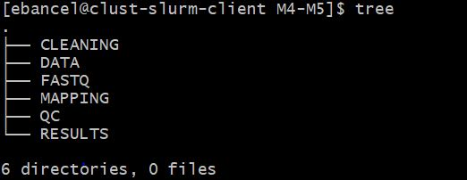

tree

```bash
[ebancel@clust-slurm-client M4-M5]$ tree
```

## Présentation des data

Données d’entrées :

```
Identifiant du run : SRR10390685
Génome de référence : NC_000964
    Gff https://ftp.ncbi.nlm.nih.gov/genomes/all/GCF/000/009/045/GCF_000009045.1_ASM904v1/GCF_000009045.1_ASM904v1_genomic.gff.gz
    Fasta https://ftp.ncbi.nlm.nih.gov/genomes/all/GCF/000/009/045/GCF_000009045.1_ASM904v1/GCF_000009045.1_ASM904v1_genomic.fna.gz
```

## Getting raw data

-Téléchargement des données d’entrée depuis les banques publiques -identifiant du run SRR10390685 -Utilisation de *sra-toolkit* -les données sont placées dans FASTQC -rw-rw-r– 1 ebancel ebancel 2.6G Jul 27 11:23 SRR10390685_1.fastq -rw-rw-r– 1 ebancel ebancel 2.6G Jul 27 11:23 SRR10390685_2.fastq

```bash
module load sra-tools
srun fasterq-dump -S -p SRR10390685 --outdir ~/M4_M5/FASTQ --threads 1
ls -lha
```

Les données concernant le Génome de référence : NC_000964 sont récupérées directement via wget et placées dans DATA

```
 wget ftp://ftp.ncbi.nlm.nih.gov/genomes/all/GCF/000/009/045/GCF_000009045.1_ASM904v1/GCF_000009045.1_ASM904v1_genomic.gff.gz

 wget ftp://ftp.ncbi.nlm.nih.gov/genomes/all/GCF/000/009/045/GCF_000009045.1_ASM904v1/GCF_000009045.1_ASM904v1_genomic.fna.gz

ls -lha

-rw-rw-r-- 1 ebancel ebancel 1.2M Jul 31 10:08 GCF_000009045.1_ASM904v1_genomic.fna.gz
-rw-rw-r-- 1 ebancel ebancel 509K Jul 31 10:07 GCF_000009045.1_ASM904v1_genomic.gff.gz
```

## Quality control

- Utilisation de *FastQc* sur les fichiers FastQ
- Compression des fichiers fastQ

Transférer le dossier fastqc du serveur sur mon poste de travail pour analyser les résultats du logiciel fastqc

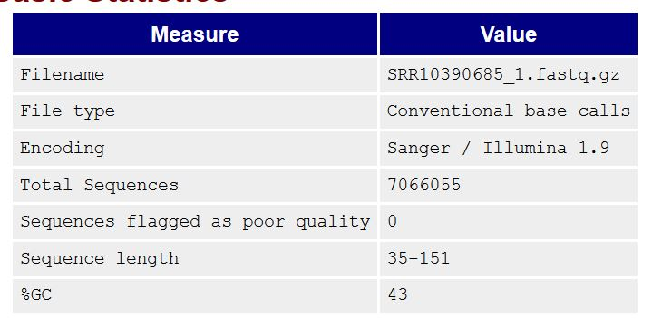

FastQCread1

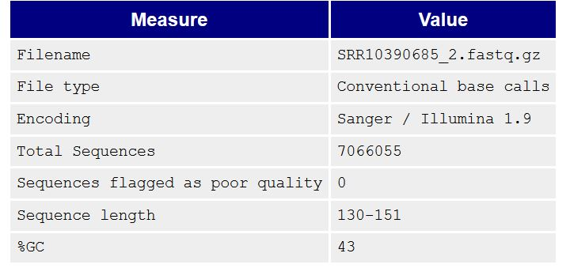

FastQCread2

#### commentaires

Les 2 graphiques représentent la qualité (score Phred, en ordonnée) de chaque base (en abscisse) pour les reads de notre jeu de données. À chaque position du read, la qualité de tous les reads est représentée sous la forme d’un boxplot. La médiane est en rouge. Le code couleur vous indique les scores de très bonne qualité en vert, bonne qualité en orange et mauvaise en rouge. La qualité baisse en fin de reads.

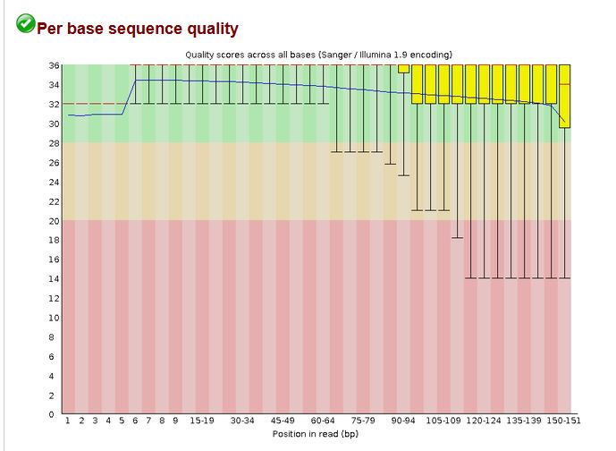

seqQuality_read1

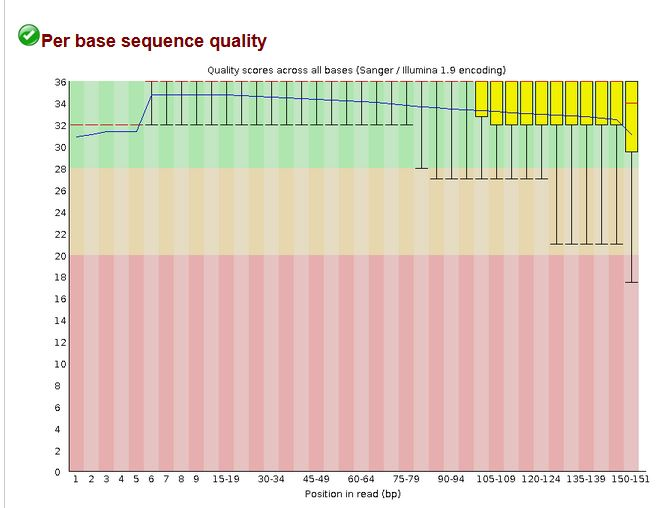

seqQuality_read2

- Quel est le nombre de séquence et la taille moyenne des séquences? *Le nombre de séquences est 7066055. La taille moyenne est 150 bp*

```
module load fastqc
gzip *fastq
ls -ltrh

module load fastqc
#attention se mettre ds M4-M5
srun --cpus-per-task 8 fastqc FASTQ/SRR10390685_1.fastq.gz -o QC/ -t 8
srun --cpus-per-task 8 fastqc FASTQ/SRR10390685_2.fastq.gz -o QC/ -t 8

ls -ltrh

# autre option srun --cpus-per-task 8 fastqc FASTQ/SRR10390685_*.fastq.gz -o QC/ -t 8
```

### Quelle est la profondeur de séquençage?

### Calcul de la profondeur de séquençage théorique

- On peut l’obtenir en faisant (total bases read1 + total bases read 2)/genome_size. Le nb de reads est dans les rapports de fastqc. nb total bases pour read 1 total bases: *1056334498* ; pour read 2 *1062807718*

La taille du génome s’obtient en utilisant *samtools faidx genome.fna.* - on génère le fichier : GCF_000009045.1_ASM904v1_genomic.fna.fai Ensuite il faut faire la somme de la colonne 2 de ce fichier pour avoir la taille complete du genome (avec un awk).

```
samtools faidx GCF_000009045.1_ASM904v1_genomic.fna

awk 'BEGIN{FS="\t";sum=0}{sum+=$2}END{print "Total genome size is " sum}' GCF_000009045.1_ASM904v1_genomic.fna.fai
```

Total genome size is **4215606**

La profondeur théorique de séquençage est **502,7X**.

## Nettoyage des reads / reads cleaning

utilisation de *fastp*

```
module load fastp

srun --cpus-per-task 8 fastp \
 --in1 FASTQ/SRR10390685_1.fastq.gz \
 --in2 FASTQ/SRR10390685_2.fastq.gz \
 -l 100 \
 --out1 CLEANING/SRR10390685_1.cleaned_filtered.fastq.gz \
 --out2 CLEANING/SRR10390685_2.cleaned_filtered.fastq.gz \
 --unpaired1 CLEANING/SRR10390685_singles.fastq.gz \
 --unpaired2 CLEANING/SRR10390685_singles.fastq.gz \
 -w 1 \
 -j CLEANING/fastp.json \
 -h CLEANING/fastp.html \
 -t 8


ls -ltrh ~/M4-M5/CLEANING/
```

### résultats

- Read1 before filtering:

total reads: 7066055

total bases: 1056334498

Q20 bases: 989425011(93.6659%)

Q30 bases: 950850058(90.0141%)

- Read2 before filtering:

total reads: 7066055

total bases: 1062807718

Q20 bases: 975887037(91.8216%)

Q30 bases: 933776181(87.8594%)

- Read1 after filtering:

total reads: 6855141

total bases: 972593291

Q20 bases: 918080212(94.3951%)

Q30 bases: 885808239(91.0769%)

- Read2 aftering filtering:

total reads: 6855141

total bases: 972626525

Q20 bases: 906379990(93.1889%)

Q30 bases: 872179928(89.6726%)

- Filtering result:

reads passed filter: 13710282

reads failed due to low quality: 356126

reads failed due to too many N: 4092

reads failed due to too short: 61610

reads with adapter trimmed: 352768

bases trimmed due to adapters: 5499206

Duplication rate: 1.17555%

Insert size peak (evaluated by paired-end reads): 250

JSON report: CLEANING/fastp.json HTML report: CLEANING/fastp.html

#### Cleaning

```
ls -ltrh ~/M4-M5/CLEANING/

--rw-rw-r-- 1 ebancel ebancel 609M Jul 31 10:26 SRR10390685_2.cleaned_filtered.fastq.gz
--rw-rw-r-- 1 ebancel ebancel 604M Jul 31 10:26 SRR10390685_1.cleaned_filtered.fastq.gz
--rw-rw-r-- 1 ebancel ebancel 132K Jul 31 10:26 fastp.json
--rw-rw-r-- 1 ebancel ebancel 475K Jul 31 10:26 fastp.html
--rw-rw-r-- 1 ebancel ebancel  15M Jul 31 10:26 SRR10390685_singles.fastq.gz
```

#### Quel % de reads sont filtrés et pourquoi?

- Filtering result

reads passed filters: 13.710282 M (97.015110%)

reads with low quality: 356.126000 K (2.519978%)

reads with too many N: 4.092000 K (0.028955%)

reads too short: 61.610000 K (0.435958%)

**3% des reads sont filtrés (faible qualité, trop de N, reads trop courts).**

#### autre possibilité : test multiQC

*MultiQC* permet de regrouper les informations provenant de multiples rapports FastQC. Il regroupe au sein d’une même page toutes les informations provenant de multiples rapports et permet une comparaison facilitée des échantillons.

```
module load multiqc
multiqc -d . -o CLEANING

ls -ltrh ~/M4-M5/CLEANING/
```

### Alignement des reads contre le génome de reférence

-mapping avec *bwa*

#### srun bwa indexing with bwa

- Pour pouvoir utiliser BWA il faut d’abord indexer le génome de référence avec la commande bwa-index.

```
module load bwa
srun bwa index GCF_000009045.1_ASM904v1_genomic.fna
#[ebancel@clust-slurm-client DATA]$ srun bwa index GCF_000009045.1_ASM904v1_genomic.fna


cd ~/M5 GCF_000009045.1_ASM904v1_genomic.fna
srun --cpus-per-task=33 bwa mem \
  /shared/home/ebancel/M4-M5/DATA/GCF_000009045.1_ASM904v1_genomic.fna  \
  CLEANING/SRR10390685_1.cleaned_filtered.fastq.gz \
  CLEANING/SRR10390685_2.cleaned_filtered.fastq.gz \
  -t 32 \
  | \
  samtools view -hbS - > MAPPING/SRR10390685.bam

  ls -ltrh ~/M5/MAPPING/
```

#### après la commande srun bwa index GCF_000009045.1_ASM904v1_genomic.fna

[ebancel@clust-slurm-client DATA]$ ls -lha total 20M drwxrwxr-x 2 ebancel ebancel 2.0M Aug 6 16:26 . drwxrwxr-x 8 ebancel ebancel 2.9M Aug 6 16:20 .. -rw-rw-r– 1 ebancel ebancel 4.1M Jul 31 10:08 GCF_000009045.1_ASM904v1_genomic.fna -rw-rw-r– 1 ebancel ebancel 12 Aug 6 16:26 GCF_000009045.1_ASM904v1_genomic.fna.amb -rw-rw-r– 1 ebancel ebancel 98 Aug 6 16:26 GCF_000009045.1_ASM904v1_genomic.fna.ann -rw-rw-r– 1 ebancel ebancel 4.1M Aug 6 16:26 GCF_000009045.1_ASM904v1_genomic.fna.bwt -rw-rw-r– 1 ebancel ebancel 1.1M Aug 6 16:26 GCF_000009045.1_ASM904v1_genomic.fna.pac -rw-rw-r– 1 ebancel ebancel 2.1M Aug 6 16:26 GCF_000009045.1_ASM904v1_genomic.fna.sa -rw-rw-r– 1 ebancel ebancel 3.5M Jul 31 10:07 GCF_000009045.1_ASM904v1_genomic.gff -rw-rw-r– 1 ebancel ebancel 758 Aug 6 16:04 trmNF.gff

```
srun --cpus-per-task=33 bwa mem \
  /shared/home/ebancel/M4-M5/DATA/GCF_000009045.1_ASM904v1_genomic.fna  \
  CLEANING/SRR10390685_1.cleaned_filtered.fastq.gz \
  CLEANING/SRR10390685_2.cleaned_filtered.fastq.gz \
  -t 32 \
  | \
  samtools view -hbS - > MAPPING/SRR10390685.bam

  ls -ltrh ~/M5/MAPPING/
```

-le bam est bien généré

[ebancel@clust-slurm-client MAPPING]$ ls -lha total 1.4G drwxrwxr-x 2 ebancel ebancel 2.9M Aug 6 16:31 . drwxrwxr-x 8 ebancel ebancel 2.9M Aug 6 16:37 .. -rw-rw-r– 1 ebancel ebancel 1.4G Aug 6 16:34 SRR10390685.bam

#### tri du bam

-le fichier SRR10390685.sorted.bam est généré

```
$ samtools sort -o SRR10390685.sorted.bam SRR10390685.bam
```

#### index du fichier sorted

-le fichier SRR10390685.sorted.bam.bai est généré. L’index BAI sert à accélerer les manipulation des BAM. Certains outils en ont absolument besoin, d’autres pas.Ici, pas besoin.

```
$ samtools index SRR10390685.sorted.bam
```

### sametools flagstat sur bam

```
$ samtools flagstat SRR10390685.sorted.bam
```

### sortie avec bam.sorted

$ samtools flagstat SRR10390685.sorted.bam

13726125 + 0 in total (QC-passed reads + QC-failed reads)

0 + 0 secondary

15843 + 0 supplementary

0 + 0 duplicates

12969706 + 0 mapped (94.49% : N/A)

13710282 + 0 paired in sequencing

6855141 + 0 read1

6855141 + 0 read2

12887940 + 0 properly paired (94.00% : N/A)

12911596 + 0 with itself and mate mapped

42267 + 0 singletons (0.31% : N/A)

0 + 0 with mate mapped to a different chr

0 + 0 with mate mapped to a different chr (mapQ>=5)

#### interprétation

- La première ligne indique combien de reads il y a dans le BAM cad ~13M
- Les supplementary alignments correspondent aux reads qui ont été splités en 2 (car ont un indel dedans)
- **La ligne 5 indique combien de reads ont été alignés contre le génome: 94% c’est très bien**.
- La ligne 9 indique, parmis les reads mappés, combien ont une distance entre la mate1 et la mate2 qui correspond à ce qui est attendu. Icila quasi totalité des reads mappent à une bonne distance l’un de l’autre.
- La ligne 10 indique combien de paires sont mappées. Ce chiffres est plus grand que le précédent car il inclut les reads pour lesquels la distance est plus grande/ plus petite que ce qui est attendu, et aussi les paires pour lesquelles les mates sont mappées sur des chromosomes différents, -Les singletons correspondent ici aux reads pour lesquels seule une des deux mates est mappée.

## Extraire dans un fichier BAM les reads chevauchant à au moins 50% le gène trmNF

Il faut extraire uniquement les informations du gène trmNF à partir de fichier gff - GCF_000009045.1_ASM904v1_genomic.gff.gz

### Récupérer les alignements sur le gène trmNF

#### dezip des fichiers fna et gff

```
gunzip GCF_000009045.1_ASM904v1_genomic.fna.gz
gunzip GCF_000009045.1_ASM904v1_genomic.gff.gz
```

#### Extraire les informations correspondant au gène d’intérêt

```
$ grep trmNF GCF_000009045.1_ASM904v1_genomic.gff | awk '$3=="gene"'> trmNF_gene.gff

#contrôle
head trmNF_gene.gff
```

#### Utilisation bedtools intersect

- Recherche info sur outils *bedtools intersect* Report the base-pair overlap between sequence alignments and genes. *By default, bedtools intersect will report an overlap between A and B so long as there is at least one base pair is overlapping. Yet sometimes you may want to restrict reported overlaps between A and B to cases where the feature in B overlaps at least X% (e.g. 50%) of the A feature. The -f option does exactly this*. *-wa write option to see the original record*
- A = fichier BAM
- B = fichier GFF (restreint au gène d’intérêt)

```
load module bedtools

#commande intersect

$  srun bedtools intersect -a MAPPING/SRR10390685.bam -b DATA/trmNF_gene.gff -f 0.50 -wa  > RESULTS/reads_on_trmNF_gene.bam
```

#### Pour connaître le nb de reads qui répondent à la condition il faut utiliser l’option ‘-c’ de samtools view:

-c print only the count of matching records

```
$ samtools view -c reads_on_trmNF_gene.bam
2848
```

Le nombre de reads chevauchant à au moins 50% le gène trmNF est **2848**.

### Présentation de l’organisation du répertoire créé en fin de projet

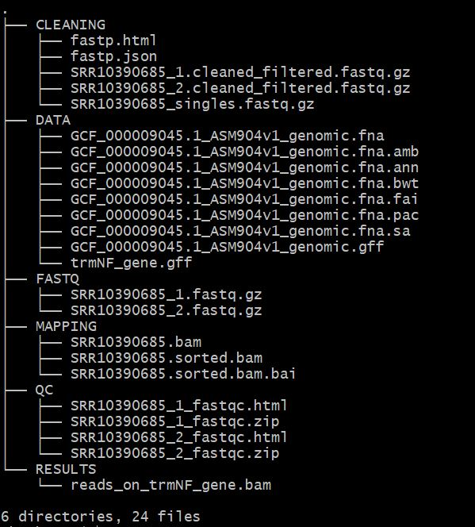

tree_end